# Preprocessing with principal components analysis(PCA)

David Asare Kumi

July 9, 2019

## Correlated Predictors

```r
library(ggplot2)
library(lattice)
library(caret)
library(kernlab)
data(spam)
inTrain <-createDataPartition(y=spam$type,p=0.75,list=FALSE)
training <-spam[inTrain,]
testing <-spam[-inTrain,]
dim(training)
```

```
## [1] 3451   58
```

```r
dim(testing)
```

```
## [1] 1150   58
```

```r
M <-abs(cor(training[,-58]))
diag(M)<-0
which(M>0.8,arr.ind=T)
```

```
##        row col
## num415  34  32
## direct  40  32
## num857  32  34
## direct  40  34
## num857  32  40
## num415  34  40
```

```r
#diag(M)<-0 means that correlation of each variable is 1, so take those correlations out. The variables num415 and num857 have very high correlation between each other.
names(spam)[c(34,32)]
```

```
## [1] "num415" "num857"
```

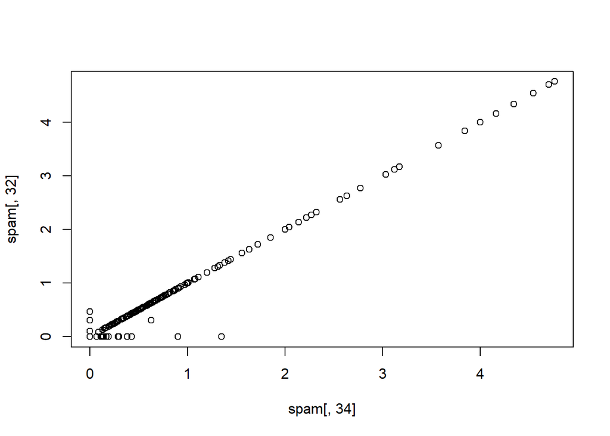

```r
plot(spam[,34],spam[,32])
```

## Basic PCA idea

- We might not need every predictor.
- A weighted combination of predictors might be better.
- We should pick this combination to capture the “most informaiton” possible.
- Benefits
1. Reduced number of predictors.
2. Reduced noise (due to averaging). Basically we are looking at the combination of the variables that explains most of the variability.

### We could rotate the plot

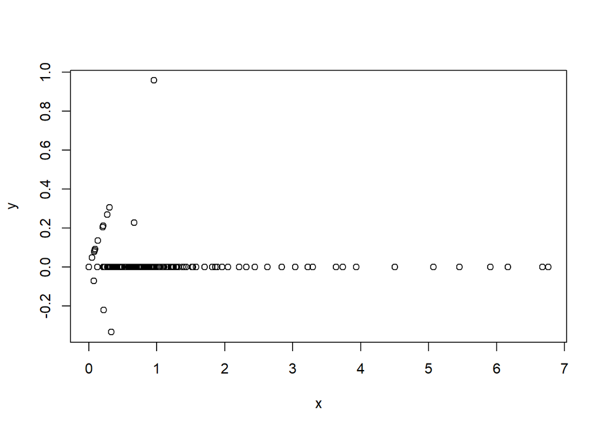

```r
x <-0.71*training$num415+0.71*training$num857
y <-0.71*training$num415-0.71*training$num857
plot(x,y)
```

## Related Problems

- You have multivariate variables X1,…,Xn so X1=(X11,…,X1m).
- Find a new set of multivariate variables that are uncorrelated and explain as much variance as possible.
- If you put all the variables together in one matrix, find the best matrix created with fewer variables(lower rank) that explains the original data.
- The first goal is statistical and the second goal is data compression. The x variable has much variability and the y variable is almost always 0.

## Principal Components in R - prcomp

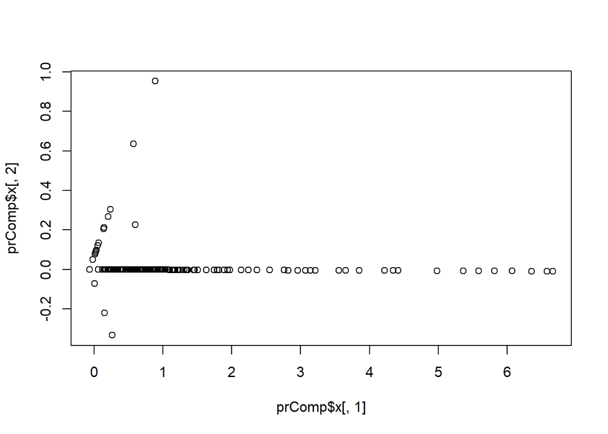

```r
library(ggplot2)
library(lattice)
library(caret)
library(kernlab)
data(spam)
smallSpam <-spam[,c(34,32)]
prComp <-prcomp(smallSpam)
plot(prComp$x[,1],prComp$x[,2])
```

```r
#principal components can let you reduce a large number of variables.

#Rotation Matrix
prComp$rotation
```

```
##              PC1        PC2
## num415 0.7080625  0.7061498
## num857 0.7061498 -0.7080625
```

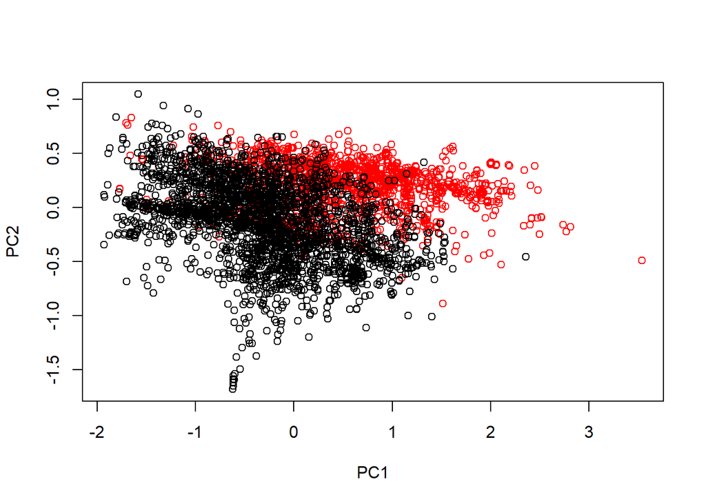

```r
#PCA on SPAM data
typeColor <-((spam$type=="spam")*1+1)
prComp <-prcomp(log10(spam[,-58]+1))
plot(prComp$x[,1],prComp$x[,2],col=typeColor,xlab="PC1",ylab="PC2")
```

```r
#PC1 is the one that explains the most variation and PC2 is the one that explains the second most variation.
```

## PCA with caret

- We can do this in caret using the preprocess function.

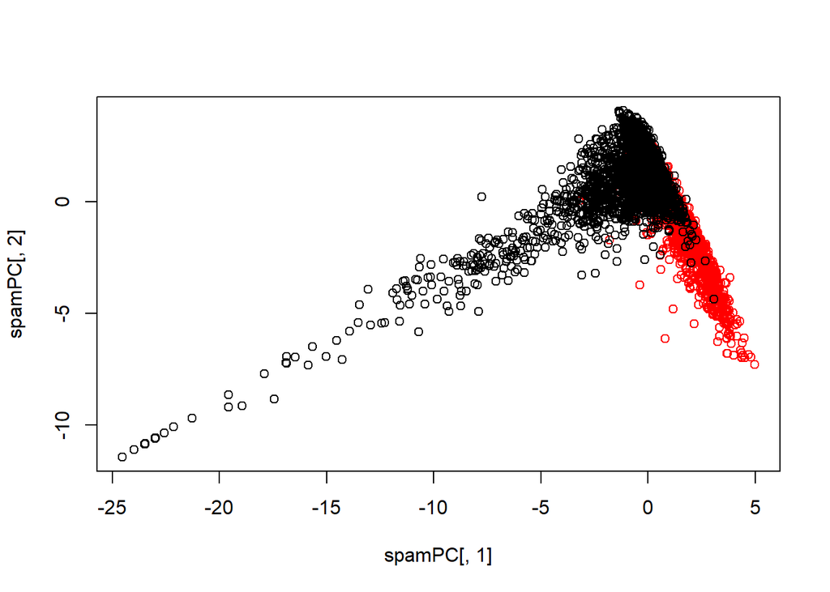

```r
library(ggplot2)
library(lattice)
library(caret)
library(kernlab)
data(spam)
inTrain <-createDataPartition(y=spam$type,p=0.75,list=FALSE)
training <-spam[inTrain,]
testing <-spam[-inTrain,]
preProc <-preProcess(log10(spam[,-58]+1),method="pca",pcaComp=2)
spamPC <-predict(preProc,log10(spam[,-58]+1))
plot(spamPC[,1],spamPC[,2],col=typeColor)
```

```r
#Preprocessing with PCA
preProc <-preProcess(log10(training[,-58]+1),method="pca",pcaComp=2)
trainPC <-predict(preProc,log10(training[,-58]+1))
testPC <-predict(preProc,log10(testing[,-58]+1))
#trainPC and testPC will give you a table of principle components.
#PCA can reduce the number of variables but maintain accuracy.
```

## Final thoughts on PCs

- Most useful for linear type models.
- Can make it harder to interpret predictors.
- Watch out for outliers!
1. Transform first (with logs/BoxCox).
2. Plot predictors to identify problems.
- For more information see
1. Exploratory Data Analysis.
2. Elements of Statistical Learning.

## Predicting with Regression

### Key ideas

- Fit a simple regression model.
- Plug in new covariates and multiply by the coefficients.
- Useful when linear model is (nearly) correct.

### Pros:

- Easy to implement.
- Easy to interpret.

### Cons:

- Often poor performance in non linear settings.

## Example: Old faithful eruptions.

```r
library(ggplot2)
library(lattice)
library(caret)
data(faithful)
dim(faithful)
```

```
## [1] 272   2
```

```r
str(faithful)
```

```
## 'data.frame':    272 obs. of  2 variables:
##  $ eruptions: num  3.6 1.8 3.33 2.28 4.53 ...
##  $ waiting  : num  79 54 74 62 85 55 88 85 51 85 ...
```

```r
summary(faithful)
```

```
##    eruptions        waiting
##  Min.   :1.600   Min.   :43.0
##  1st Qu.:2.163   1st Qu.:58.0
##  Median :4.000   Median :76.0
##  Mean   :3.488   Mean   :70.9
##  3rd Qu.:4.454   3rd Qu.:82.0
##  Max.   :5.100   Max.   :96.0
```

```r
set.seed(333) # so that this can be reproduced
inTrain <-createDataPartition(y=faithful$eruptions,p=0.5,list=FALSE)
trainFaith <-faithful[inTrain,]
testFaith <-faithful[-inTrain,]
#Eruption Duration versus waiting time
plot(trainFaith$waiting,trainFaith$eruptions,pch=20,cex=1,col="blue",xlab="Waiting",ylab="Duration")
#Fit a linear model
fit <-lm(eruptions~waiting,data=trainFaith)
summary(fit)
```

```
##
## Call:
## lm(formula = eruptions ~ waiting, data = trainFaith)
##
## Residuals:
##      Min       1Q   Median       3Q      Max
## -1.29250 -0.37706  0.00889  0.37091  1.07341
##
## Coefficients:
##              Estimate Std. Error t value Pr(>|t|)
## (Intercept) -1.964020   0.233116  -8.425 4.93e-14 ***
## waiting      0.076930   0.003232  23.806  < 2e-16 ***
## ---
## Signif. codes:  0 '***' 0.001 '**' 0.01 '*' 0.05 '.' 0.1 ' ' 1
##
## Residual standard error: 0.5004 on 134 degrees of freedom
## Multiple R-squared:  0.8088, Adjusted R-squared:  0.8073
## F-statistic: 566.7 on 1 and 134 DF,  p-value: < 2.2e-16
```

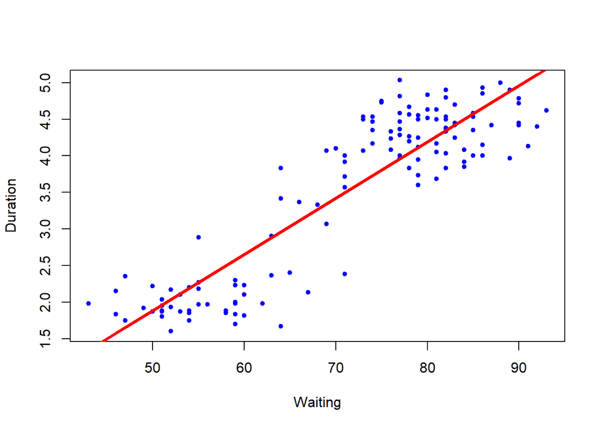

```r
lines(trainFaith$waiting,fit$fitted,lwd=3,col="red")
```

```r
#Predict a new value
coef(fit)[1]+coef(fit)[2]*80
```

```
## (Intercept)
##    4.190378
```

```r
#Alternative approach
newdata <-data.frame(waiting=80)
predict(fit,newdata)
```

```
##        1
## 4.190378
```

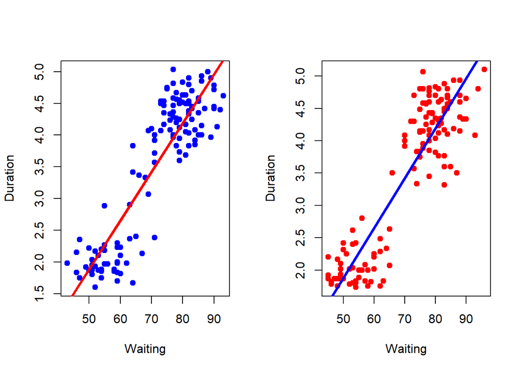

```r
#Plot predictions-training and test
par(mfrow=c(1,2))
plot(trainFaith$waiting,trainFaith$eruptions,pch=19,col="blue",xlab="Waiting",ylab="Duration")
lines(trainFaith$waiting,predict(fit),lwd=3,col="red")
plot(testFaith$waiting,testFaith$eruptions,pch=19,col="red",xlab="Waiting",ylab="Duration")
lines(testFaith$waiting,predict(fit,newdata=testFaith),lwd=3,col="blue")
```

```r
#calculate RMSE on training set
sqrt(sum((fit$fitted-trainFaith$eruptions)^2))
```

```
## [1] 5.792106
```

```r
#Calculate RMSE on the test set
sqrt(sum((predict(fit,newdata=testFaith)-testFaith$eruptions)^2))
```

```
## [1] 5.753229
```

```r
#RMSE measures how close the fitted values are to the observed (real) values.
```

## Prediction Intervals

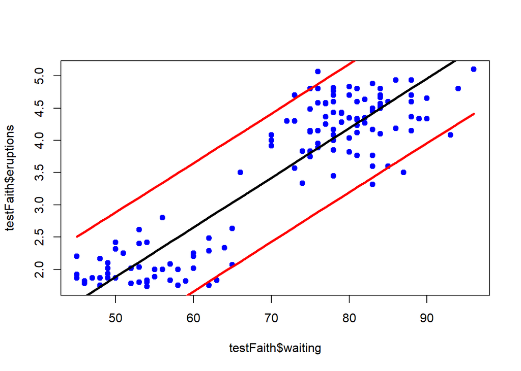

```r
pred1 <-predict(fit,newdata=testFaith,interval="prediction")
ord <-order(testFaith$waiting)
plot(testFaith$waiting,testFaith$eruptions,pch=19,col="blue")
matlines(testFaith$waiting[ord],pred1[ord,],type="l",col=c(1,2,2),lty=c(1,1,1),lwd=3)
```

```r
#Same process with caret
modFit <-train(eruptions~waiting,data=trainFaith,method="lm")
summary(modFit$finalModel)
```

```
##
## Call:
## lm(formula = .outcome ~ ., data = dat)
##
## Residuals:
##      Min       1Q   Median       3Q      Max
## -1.29250 -0.37706  0.00889  0.37091  1.07341
##
## Coefficients:
##              Estimate Std. Error t value Pr(>|t|)
## (Intercept) -1.964020   0.233116  -8.425 4.93e-14 ***
## waiting      0.076930   0.003232  23.806  < 2e-16 ***
## ---
## Signif. codes:  0 '***' 0.001 '**' 0.01 '*' 0.05 '.' 0.1 ' ' 1
##
## Residual standard error: 0.5004 on 134 degrees of freedom
## Multiple R-squared:  0.8088, Adjusted R-squared:  0.8073
## F-statistic: 566.7 on 1 and 134 DF,  p-value: < 2.2e-16
```

## Notes and Further Reading

- Regression models with multiple covariates can be concluded.
- Often useful in combination with other models.
- Elements of Statistical Learning.
- Modern Applied Statistics with S.
- Introduction to Statistical Learning.

## Predicting with Regression

### Example: Wage data

```r
library(ggplot2)
library(lattice)
library(caret)
library(ISLR)
data(Wage)
dim(Wage)
```

```
## [1] 3000   11
```

```r
names(Wage)
```

```
##  [1] "year"       "age"        "maritl"     "race"       "education"
##  [6] "region"     "jobclass"   "health"     "health_ins" "logwage"
## [11] "wage"
```

```r
str(Wage)
```

```
## 'data.frame':    3000 obs. of  11 variables:
##  $ year      : int  2006 2004 2003 2003 2005 2008 2009 2008 2006 2004 ...
##  $ age       : int  18 24 45 43 50 54 44 30 41 52 ...
##  $ maritl    : Factor w/ 5 levels "1. Never Married",..: 1 1 2 2 4 2 2 1 1 2 ...
##  $ race      : Factor w/ 4 levels "1. White","2. Black",..: 1 1 1 3 1 1 4 3 2 1 ...
##  $ education : Factor w/ 5 levels "1. < HS Grad",..: 1 4 3 4 2 4 3 3 3 2 ...
##  $ region    : Factor w/ 9 levels "1. New England",..: 2 2 2 2 2 2 2 2 2 2 ...
##  $ jobclass  : Factor w/ 2 levels "1. Industrial",..: 1 2 1 2 2 2 1 2 2 2 ...
##  $ health    : Factor w/ 2 levels "1. <=Good","2. >=Very Good": 1 2 1 2 1 2 2 1 2 2 ...
##  $ health_ins: Factor w/ 2 levels "1. Yes","2. No": 2 2 1 1 1 1 1 1 1 1 ...
##  $ logwage   : num  4.32 4.26 4.88 5.04 4.32 ...
##  $ wage      : num  75 70.5 131 154.7 75 ...
```

```r
Wage <-subset(Wage,select=-c(logwage))
summary(Wage)
```

```
##       year           age                     maritl           race
##  Min.   :2003   Min.   :18.00   1. Never Married: 648   1. White:2480
##  1st Qu.:2004   1st Qu.:33.75   2. Married      :2074   2. Black: 293
##  Median :2006   Median :42.00   3. Widowed      :  19   3. Asian: 190
##  Mean   :2006   Mean   :42.41   4. Divorced     : 204   4. Other:  37
##  3rd Qu.:2008   3rd Qu.:51.00   5. Separated    :  55
##  Max.   :2009   Max.   :80.00
##
##               education                     region
##  1. < HS Grad      :268   2. Middle Atlantic   :3000
##  2. HS Grad        :971   1. New England       :   0
##  3. Some College   :650   3. East North Central:   0
##  4. College Grad   :685   4. West North Central:   0
##  5. Advanced Degree:426   5. South Atlantic    :   0
##                           6. East South Central:   0
##                           (Other)              :   0
##            jobclass               health      health_ins
##  1. Industrial :1544   1. <=Good     : 858   1. Yes:2083
##  2. Information:1456   2. >=Very Good:2142   2. No : 917
##
##
##
##
##
##       wage
##  Min.   : 20.09
##  1st Qu.: 85.38
##  Median :104.92
##  Mean   :111.70
##  3rd Qu.:128.68
##  Max.   :318.34
##
```

```r
#Getting training and test sets
inTrain <-createDataPartition(y=Wage$wage,p=0.7,list=FALSE)
training <-Wage[inTrain,]
testing <-Wage[-inTrain,]
dim(training)
```

```
## [1] 2102   10
```

```r
dim(testing)
```

```
## [1] 898  10
```

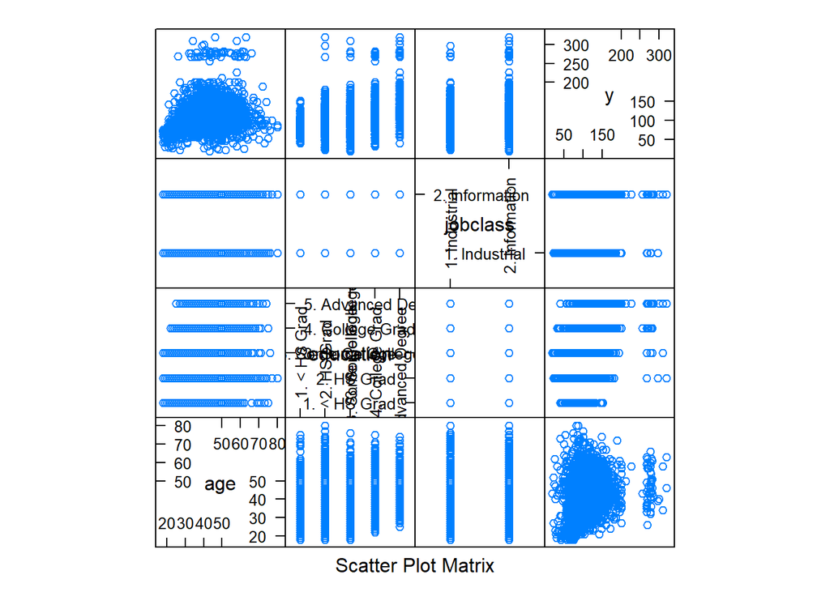

```r
#Feature plot
featurePlot(x=training[,c("age","education","jobclass")],y=training$wage,plot="pairs")
```

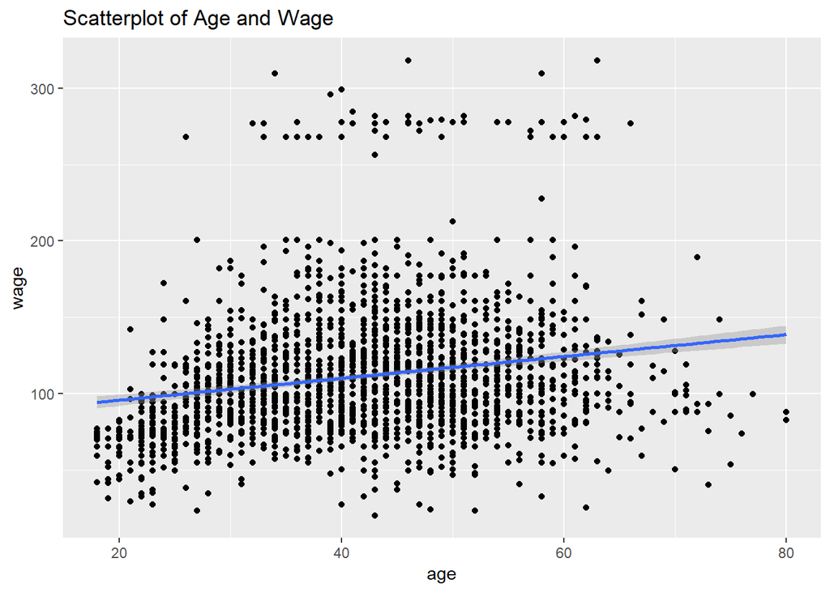

```r
#Plot age versus wage
qplot(age,wage,data=training,main="Scatterplot of Age and Wage")+geom_smooth(method="lm")
```

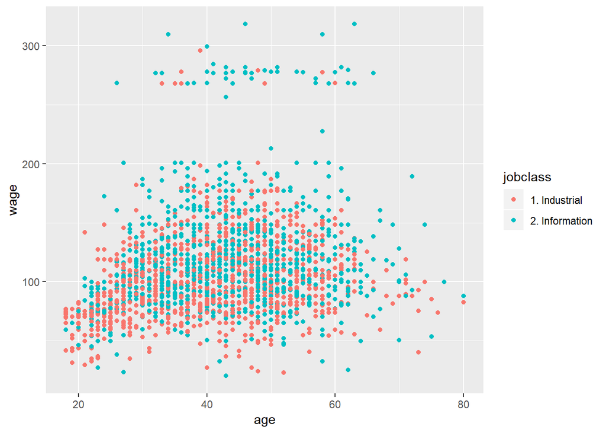

```r
#Plot age versus wage,color by jobclass
qplot(age,wage,color=jobclass,data=training)
```

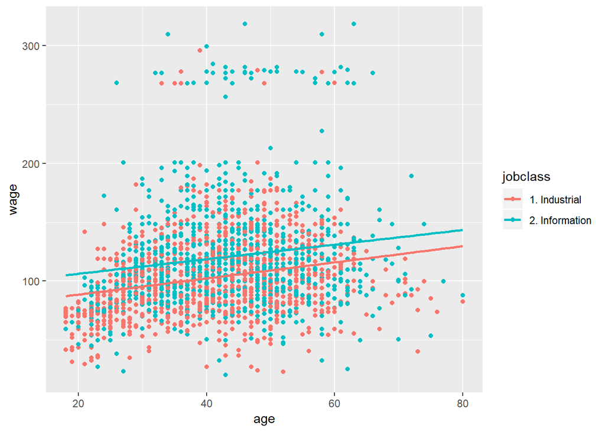

```r
qplot(age,wage,color=jobclass,data=training)+geom_smooth(method="lm",se=FALSE)
```

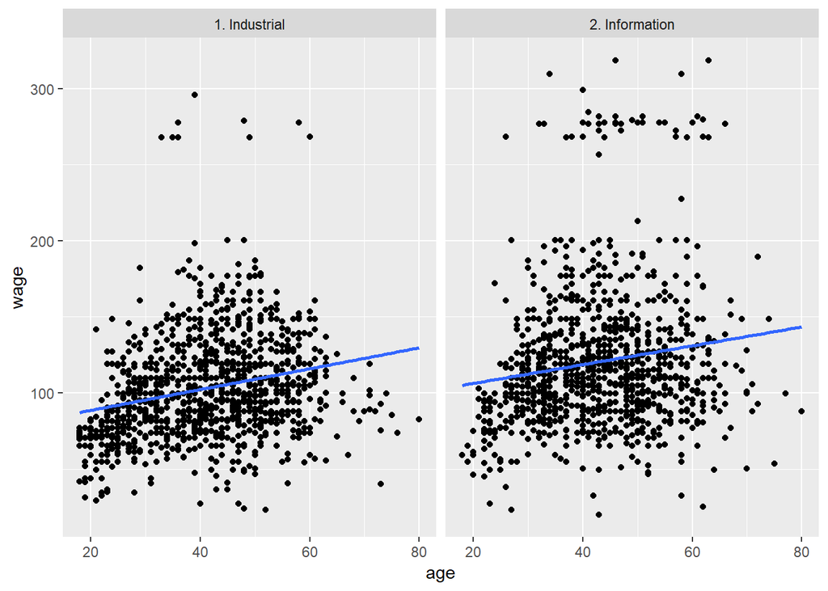

```r
qplot(age,wage,data=training,facets=.~jobclass)+geom_smooth(method="lm",se=FALSE)
```

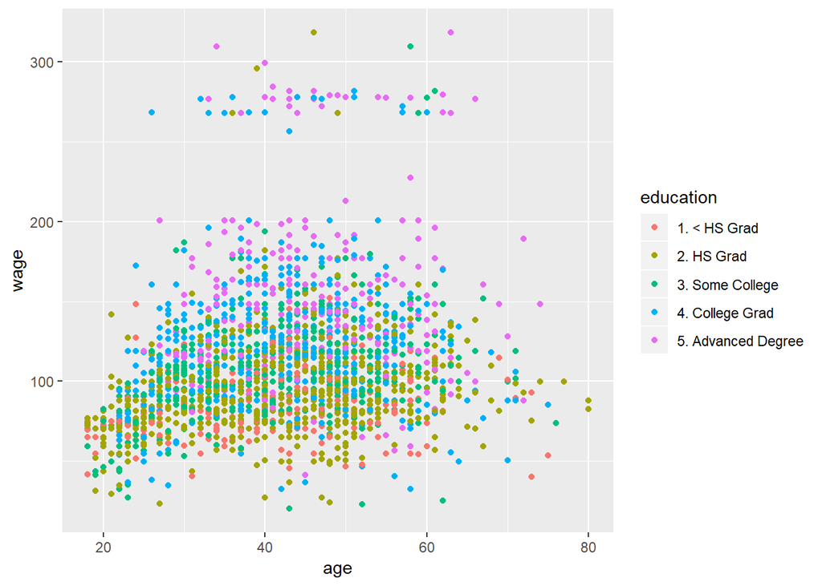

```r
#Plot age versus wage,color by education
qplot(age,wage,color=education,data=training)
```

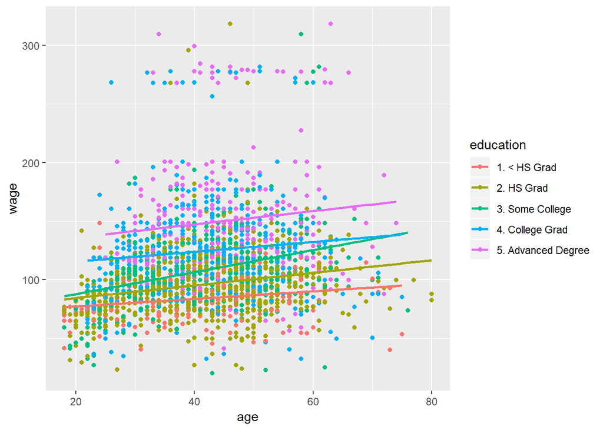

```r
qplot(age,wage,color=education,data=training)+geom_smooth(method="lm",se=FALSE)
```

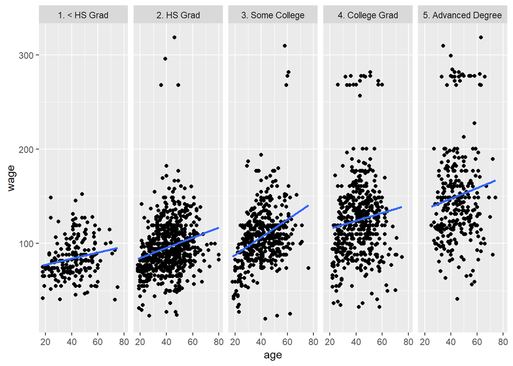

```r
qplot(age,wage,data=training,facets=.~education)+geom_smooth(method="lm",se=FALSE)
```

```r
#These plots help us explain the factors influencing the variations in the upper part of the plot.

#Fit a linear Model
modFit <-train(wage~age+jobclass+education,method="lm",data=training)
modFit
```

```
## Linear Regression
##
## 2102 samples
##    3 predictor
##
## No pre-processing
## Resampling: Bootstrapped (25 reps)
## Summary of sample sizes: 2102, 2102, 2102, 2102, 2102, 2102, ...
## Resampling results:
##
##   RMSE      Rsquared   MAE
##   35.51674  0.2533017  24.54758
##
## Tuning parameter 'intercept' was held constant at a value of TRUE
```

```r
finMod <-modFit$finalModel
finMod
```

```
##
## Call:
## lm(formula = .outcome ~ ., data = dat)
##
## Coefficients:
##                   (Intercept)                            age
##                       59.3746                         0.5657
##      `jobclass2. Information`          `education2. HS Grad`
##                        4.9969                        11.4486
##    `education3. Some College`     `education4. College Grad`
##                       22.5278                        38.6678
## `education5. Advanced Degree`
##                       61.4803
```

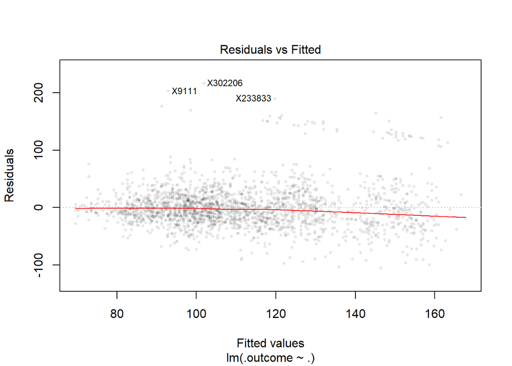

```r
#Diagnostics
plot(finMod,1,pch=19,cex=0.5,col="#00000010") # 1 is the first plot in the diagnostic plot
```

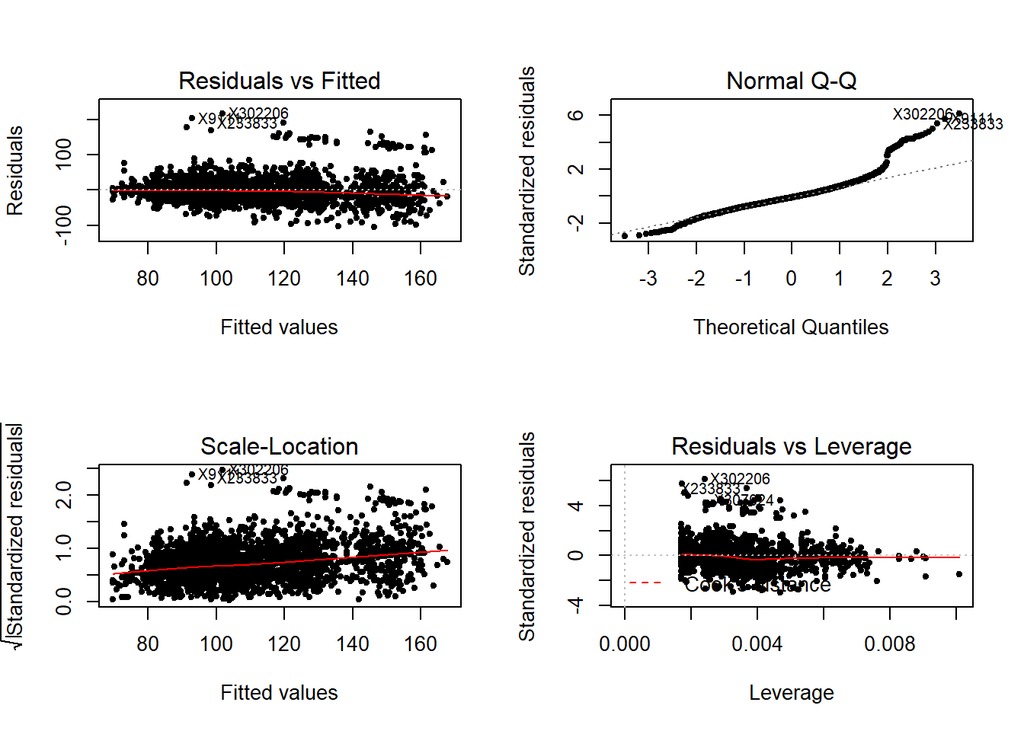

```r
par(mfrow=c(2,2))
plot(finMod,pch=20,cex=1)
```

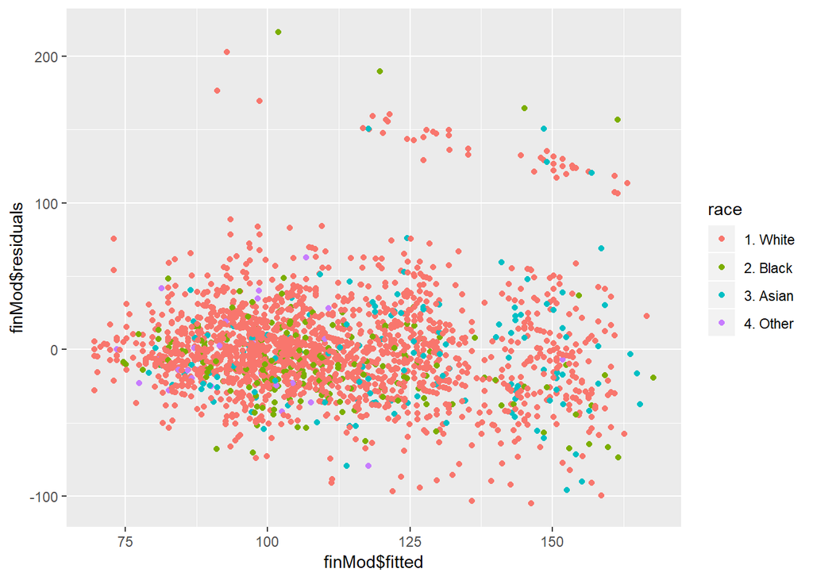

```r
#Color by variables not used in the model
qplot(finMod$fitted,finMod$residuals,color=race,data=training)
```

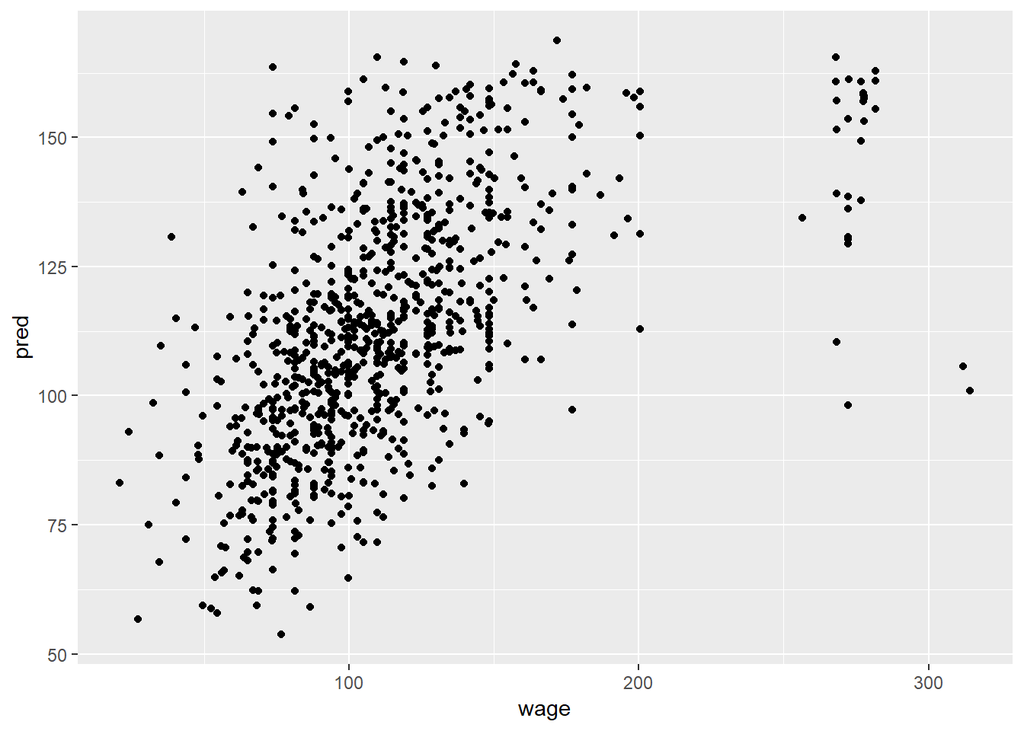

```r
#Plot by index
plot(finMod$residuals,pch=20)

#Predicted versus truth in test set
pred <-predict(modFit,testing)
qplot(wage,pred,color=year,data=testing)

#If you want to use all covariates
modFitAll <-train(wage~.,data=training,method="lm")
pred <-predict(modFitAll,testing)
qplot(wage,pred,data=testing)
```

[output not shown]

## Predicting with Trees

### Key Ideas

- Iteratively split variables into groups.
- Evaluate “homogeneity” within each group.
- Split again if necessary. We split the variables to predict the outcome. Groups must be homogeneous or small enough before you stop.

### Pros

- Easy to interpret.
- Better performance in non linear settings.

### Cons

- Without pruning/cross-validation can lead to over-fitting.
- Harder to estimate uncertainty.
- Results may be variable.

## Basic Algorithm

- Start with all variables in one group.
- Find the variable/split that best separates the outcomes.
- Divide the data into two groups (“leaves”) on that split(“node”).
- Within each split, find the best variable/split that separates the outcomes.
- Continue untill the groups are too small or sufficiently “pure”-i.e. sufficiently homogeneous.

## Example:Iris Data

```r
library(ggplot2)
library(lattice)
library(caret)
data(iris)
names(iris)
```

```
## [1] "Sepal.Length" "Sepal.Width"  "Petal.Length" "Petal.Width"
## [5] "Species"
```

```r
str(iris)
```

```
## 'data.frame':    150 obs. of  5 variables:
##  $ Sepal.Length: num  5.1 4.9 4.7 4.6 5 5.4 4.6 5 4.4 4.9 ...
##  $ Sepal.Width : num  3.5 3 3.2 3.1 3.6 3.9 3.4 3.4 2.9 3.1 ...
##  $ Petal.Length: num  1.4 1.4 1.3 1.5 1.4 1.7 1.4 1.5 1.4 1.5 ...
##  $ Petal.Width : num  0.2 0.2 0.2 0.2 0.2 0.4 0.3 0.2 0.2 0.1 ...
##  $ Species     : Factor w/ 3 levels "setosa","versicolor",..: 1 1 1 1 1 1 1 1 1 1 ...
```

```r
table(iris$Species)
```

```
##
##     setosa versicolor  virginica
##         50         50         50
```

```r
#Create training and test sets
inTrain <-createDataPartition(y=iris$Species,p=0.7,list=FALSE)
training <-iris[inTrain,]
testing <-iris[-inTrain,]
dim(training)
```

```
## [1] 105   5
```

```r
dim(testing)
```

```
## [1] 45  5
```

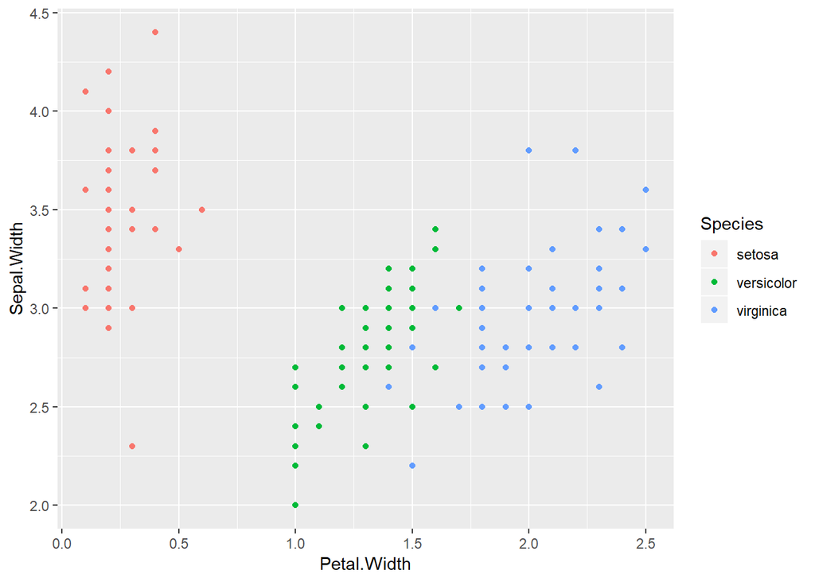

```r
qplot(Petal.Width,Sepal.Width,color=Species,data=iris)
```

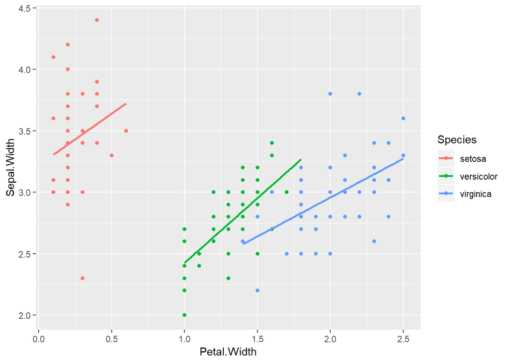

```r
qplot(Petal.Width,Sepal.Width,color=Species,data=iris)+geom_smooth(method="lm",se=FALSE)
```

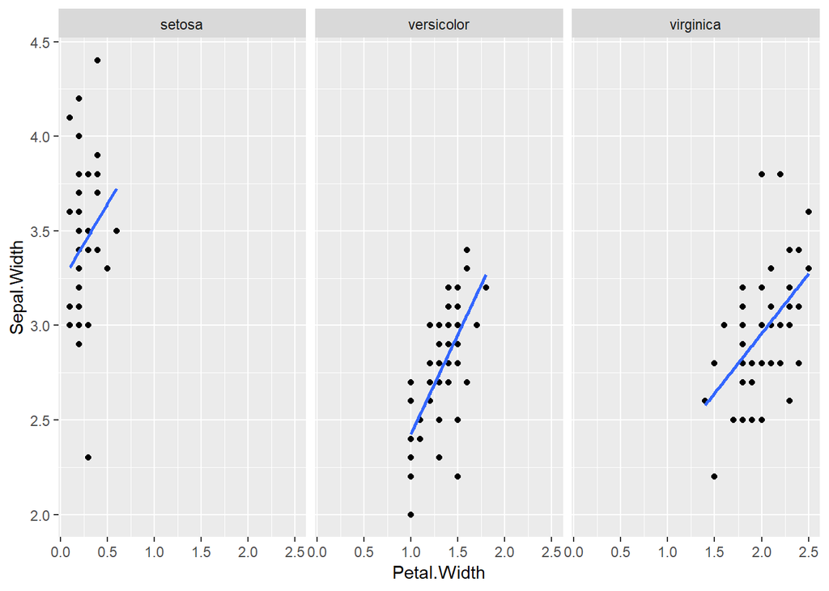

```r
qplot(Petal.Width,Sepal.Width,data=iris,facets=.~Species)+geom_smooth(method="lm",se=FALSE)
```

```r
#Fit the model
library(rpart)
modFit <-train(Species~.,method="rpart",data=training)
modFit$finalModel
```

```
## n= 105
##
## node), split, n, loss, yval, (yprob)
##       * denotes terminal node
##
## 1) root 105 70 setosa (0.3333333 0.3333333 0.3333333)
##   2) Petal.Length< 2.6 35  0 setosa (1.0000000 0.0000000 0.0000000) *
##   3) Petal.Length>=2.6 70 35 versicolor (0.0000000 0.5000000 0.5000000)
##     6) Petal.Width< 1.75 38  4 versicolor (0.0000000 0.8947368 0.1052632) *
##     7) Petal.Width>=1.75 32  1 virginica (0.0000000 0.0312500 0.9687500) *
```

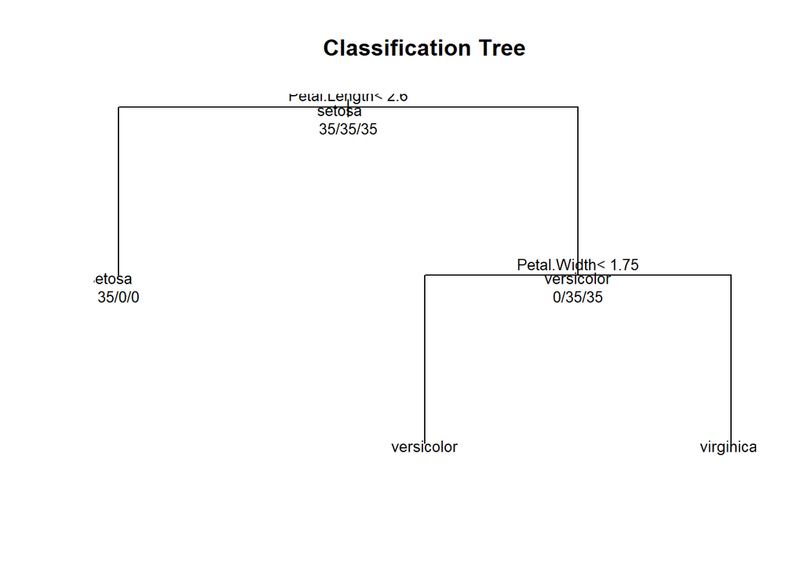

```r
plot(modFit$finalModel,uniform=TRUE,main="Classification Tree")
text(modFit$finalModel,use.n=TRUE,all=TRUE,cex=0.8)
```

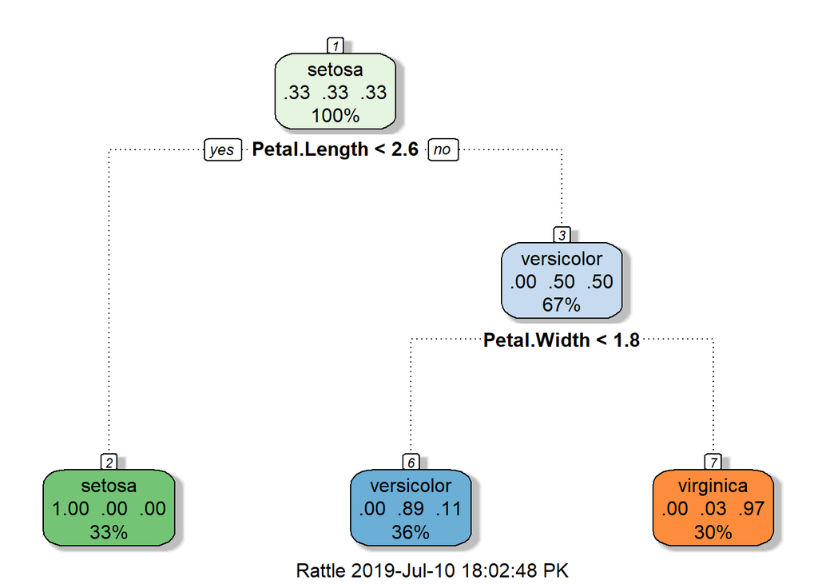

```r
#install.packages("rattle",dependencies=c("depends","suggests"))
library(rattle)
fancyRpartPlot(modFit$finalModel)
```

```r
#Predicting new values
predict(modFit,newdata=testing)
```

```
##  [1] setosa     setosa     setosa     setosa     setosa     setosa
##  [7] setosa     setosa     setosa     setosa     setosa     setosa
## [13] setosa     setosa     setosa     versicolor versicolor versicolor
## [19] versicolor versicolor versicolor versicolor versicolor versicolor
## [25] versicolor versicolor versicolor versicolor versicolor versicolor
## [31] virginica  virginica  virginica  virginica  virginica  virginica
## [37] virginica  virginica  virginica  virginica  virginica  versicolor
## [43] virginica  virginica  virginica
## Levels: setosa versicolor virginica
```

## Notes and further resources

- Classification trees are non-linear models.
1. They use interactions between variables.
2. Data transformations may be less important(monotone transformations).
3. Trees can also be used for regression problems(continuous outcomes).
- Note that there are multiple treee building options in R both in the caret package-party, rpart and out of the caret package-tree.

### Resources

- Introduction to Statistical Learning.
- Element of Statistical Learning.
- Classification and regression trees.

## Bagging:Bootstrap Aggregating(bagging)

### Basic Idea

1. Resample cases and recalculate predictions.
2. Average or majority vote.

### Notes

- Similar Bias.
- Reduced Variance.
- More useful for non-linear functions.
- Also useful for things like predicting with trees.

## Example:Ozone Data

```r
library(ElemStatLearn)
data(ozone)
names(ozone)
```

```
## [1] "ozone"       "radiation"   "temperature" "wind"
```

```r
ozone <-ozone[order(ozone$ozone),]
dim(ozone)
```

```
## [1] 111   4
```

```r
head(ozone)
```

```
##     ozone radiation temperature wind
## 17      1         8          59  9.7
## 19      4        25          61  9.7
## 14      6        78          57 18.4
## 45      7        48          80 14.3
## 106     7        49          69 10.3
## 7       8        19          61 20.1
```

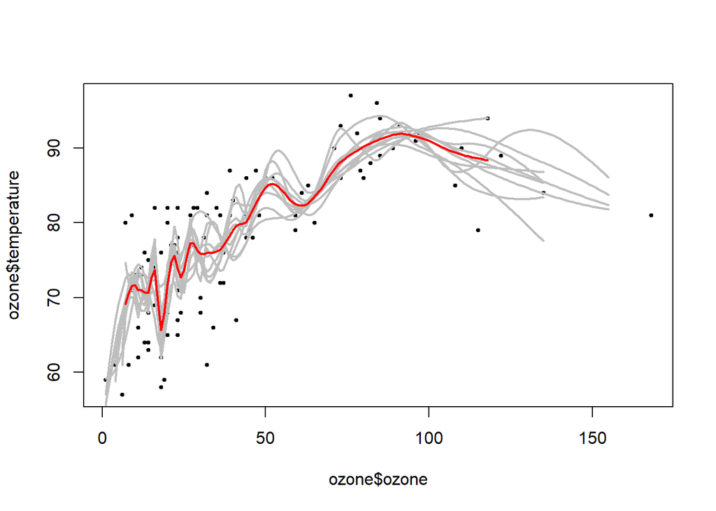

```r
#We are going to try to predict temperature as a function of ozone

#Bagged loess
ll <-matrix(NA,nrow=10,ncol=155)
for (i in 1:10){
  ss <-sample(1:dim(ozone)[1],replace=T)
  ozone0 <-ozone[ss,]
  ozone0 <-ozone0[order(ozone0$ozone),]
  loess0 <-loess(temperature~ozone,data=ozone0,span=0.2)
  ll[i,] <-predict(loess0,newdata=data.frame(ozone=1:155))
}
#span=0.2 tells the smoothness of the curve
plot(ozone$ozone,ozone$temperature,pch=19,cex=0.5)
for(i in 1:10){
  lines(1:155,ll[i,],col="grey",lwd=2)
}
lines(1:155,apply(ll,2,mean),col="red",lwd=2)
```

```r
#The grey lines have a lot of curviness (overcapture the variability). The red line is the bagged curve (average of multiple loess curve). It is in the middle.
```

## Bagging in Caret

- Some models perform bagging for you, in train function consider method options;
1. bagEarth
2. treebag
3. bagFDA
- Alternatively you can bag any model you choose using the bag function.

## More bagging in caret (Custom bagging)

- Alternatively you can build your own bagging.

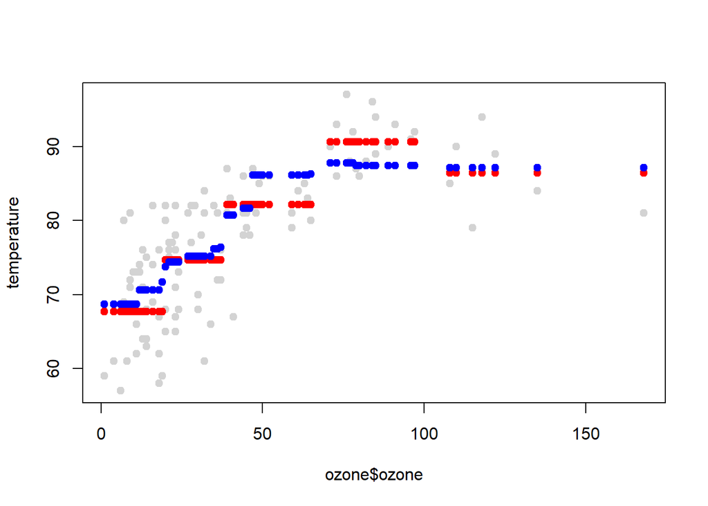

```r
library(party)
predictors <-data.frame(ozone=ozone$ozone)
temperature <-ozone$temperature
treebag <-bag(predictors,temperature,B=10,bagControl=bagControl(fit=ctreeBag$fit,predict=ctreeBag$pred,aggregate=ctreeBag$aggregate))
#B=10 is the number of replication(number of subsamples)
#aggregate; for example you can average the predictions.
plot(ozone$ozone,temperature,col="lightgrey",pch=19)
points(ozone$ozone,predict(treebag$fits[[1]]$fit,predictors),pch=19,col="red")
points(ozone$ozone,predict(treebag,predictors),pch=19,col="blue")
```

## Parts of bagging

1. ctreeBag$fit.
2. ctree$pred.
3. ctreeBag$aggregate.

## Notes and further resources

### Notes

- Bagging is most useful for non-linear models.
- Often used with trees - an extension is random forest.
- Several models use bagging in caret’s train function.

### Further resources

- Bagging.
- Bagging and boosting.
- Elements of Statistical Learning.